# Lab 9 Part 2: Attention — and the Line You Cannot Forget

ECON 8310: Business Forecasting — University of Nebraska at Omaha

# What we are doing

Last week’s recurrent models read the window one step at a time. Attention does not: every position looks at every other position at once, so week 3 reaches week 50 in a single operation rather than through forty-seven state updates.

Today you build a Transformer encoder, then delete one line from it and watch it fall apart. That line is the one PyTorch does not add for you, and forgetting it is the most common way this architecture fails silently.

**Suggested time:** ~40 minutes · **You will need:** `pandas`, `numpy`, `matplotlib`, `torch`, and `data/processed/m5_weekly.csv`.

**This lab is slow**

Attention is $O(T^2)$ in sequence length, and we use a 52-week window. A single fit takes about 70 seconds and Step 3 trains four of them. Start the cell, read while it runs.

# Setup

```python
import pandas as pd
import numpy as np
import matplotlib.pyplot as plt
import math
import torch
import torch.nn as nn
import warnings
warnings.filterwarnings('ignore')

from pathlib import Path

def data_path(name):
    for base in (Path.cwd(), *Path.cwd().parents):
        p = base / "data" / "processed" / name
        if p.exists():
            return p
    raise FileNotFoundError(
        f"Could not find data/processed/{name}. "
        "Run `python scripts/prep_m5.py` from the repository root first.")

weekly = (pd.read_csv(data_path("m5_weekly.csv"), parse_dates=["week_start"])
            .sort_values(["store_id", "cat_id", "week_start"]))
CHANNELS, WINDOW = ["units", "snap_days", "event_days", "avg_price"], 52
CUTOFF = np.datetime64("2015-05-17")
rmse = lambda a, b: float(np.sqrt(np.mean((np.asarray(a) - np.asarray(b)) ** 2)))

X, Y, D = [], [], []
for _, g in weekly.groupby(["store_id", "cat_id"]):
    arr, dates = g[CHANNELS].values.astype("float32"), g.week_start.values
    for i in range(len(g) - WINDOW):
        X.append(arr[i:i+WINDOW]); Y.append(arr[i+WINDOW, 0]); D.append(dates[i+WINDOW])
X = np.stack(X); Y = np.array(Y, dtype="float32"); D = np.array(D)
tr, te = D < CUTOFF, D >= CUTOFF
mu, sd = X[tr].mean((0,1), keepdims=True), X[tr].std((0,1), keepdims=True) + 1e-8
ym, ys = Y[tr].mean(), Y[tr].std()
Xn, Yn = (X - mu)/sd, (Y - ym)/ys
X_tr, y_tr, X_te = torch.tensor(Xn[tr]), torch.tensor(Yn[tr]), torch.tensor(Xn[te])
print(f"{X.shape[0]:,} windows of {WINDOW} weeks — train {tr.sum():,}, test {te.sum():,}")
```

```
6,750 windows of 52 weeks — train 5,160, test 1,590
```

# Step 1 — Positional encoding, before the model

Attention computes a **weighted average** over positions. Averaging does not care about order: shuffle the input and each week’s attention output is unchanged, only moved along with its week.

So position has to be added to the input itself. The standard device is a set of sinusoids of different frequencies.

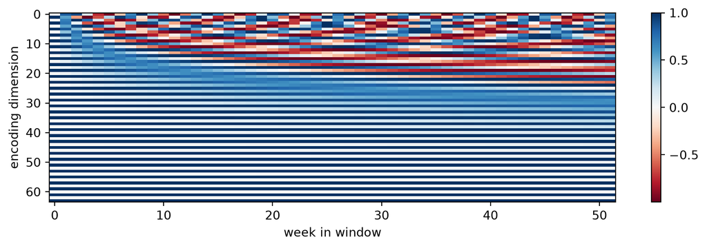

```python
def sinusoidal(seq_len, d_model):
    pe = torch.zeros(seq_len, d_model)
    pos = torch.arange(seq_len).unsqueeze(1).float()
    div = torch.exp(torch.arange(0, d_model, 2).float() * (-math.log(10000.0) / d_model))
    pe[:, 0::2] = torch.sin(pos * div)
    pe[:, 1::2] = torch.cos(pos * div)
    return pe.unsqueeze(0)

pe = sinusoidal(WINDOW, 64)
fig, ax = plt.subplots(figsize=(9, 3))
im = ax.imshow(pe[0].T, aspect="auto", cmap="RdBu")
ax.set_xlabel("week in window"); ax.set_ylabel("encoding dimension")
plt.colorbar(im); plt.tight_layout()
```

**Read the picture.** Every column — every week — has a distinct pattern down the dimensions, so the model can tell positions apart. Nearby columns look similar, so it can also learn *relative* distance rather than only absolute index.

# Step 2 — Build the encoder

```python
class TransformerForecaster(nn.Module):
    def __init__(self, n_channels=4, d_model=64, nhead=4, layers=2, use_pe=True):
        super().__init__()
        self.use_pe = use_pe
        self.inp = nn.Linear(n_channels, d_model)
        self.register_buffer("pe", sinusoidal(WINDOW, d_model))
        enc_layer = nn.TransformerEncoderLayer(
            d_model=d_model, nhead=nhead, dim_feedforward=128,
            dropout=0.1, batch_first=True)
        self.enc = nn.TransformerEncoder(enc_layer, num_layers=layers)
        self.fc = nn.Linear(d_model, 1)

    def forward(self, x):
        h = self.inp(x)
        if self.use_pe:
            h = h + self.pe                 # <- the line in question
        return self.fc(self.enc(h)[:, -1, :]).squeeze(-1)

def train(use_pe, seed, epochs=30):
    torch.manual_seed(seed)
    model = TransformerForecaster(use_pe=use_pe)
    opt = torch.optim.Adam(model.parameters(), lr=1e-3, weight_decay=1e-4)
    lossfn = nn.MSELoss()
    loader = torch.utils.data.DataLoader(
        torch.utils.data.TensorDataset(X_tr, y_tr), batch_size=128, shuffle=False)
    for _ in range(epochs):
        model.train()
        for xb, yb in loader:
            opt.zero_grad()
            lossfn(model(xb), yb).backward()
            torch.nn.utils.clip_grad_norm_(model.parameters(), 1.0)
            opt.step()
    model.eval()
    with torch.no_grad():
        return rmse(Y[te], model(X_te).numpy() * ys + ym), sum(p.numel() for p in model.parameters())

score, n_par = train(use_pe=True, seed=1)
print(f"Transformer — {n_par:,} parameters, test RMSE {score:,.0f}")
```

```
Transformer — 67,329 parameters, test RMSE 1,013
```

**Note the parameter count** against last week’s models: the RNN had 4,545 and won.

# Step 3 — Delete the line

Same model, same data, same seeds — `use_pe=False` removes the single addition in `forward`.

```python
rows = []
for use_pe in (True, False):
    runs = [train(use_pe, s)[0] for s in (1, 2)]
    rows.append({"positional encoding": "yes" if use_pe else "no",
                 "mean": round(np.mean(runs)), "sd": round(np.std(runs)),
                 "runs": [round(r) for r in runs]})
print(pd.DataFrame(rows).to_string(index=False))
```

```
positional encoding  mean  sd         runs
                yes   990  23  [1013, 967]
                 no  1282   8 [1290, 1274]
```

**Nothing raised an exception**

The model without positional encoding trained happily, converged, and returned forecasts. It still knew which week was most recent, because it reads its forecast from the last position, but it saw the other 51 as an **unordered bag** — it could not tell two weeks ago from a year ago.

Compare the gap against the run-to-run spread in the `sd` column. This is not noise.

`nn.TransformerEncoderLayer` gives you attention, residuals, layer norm and the feed-forward sublayer. It does **not** give you position. That is yours to add, and nothing checks that you did.

**Your turn:** express the penalty as a percentage of the with-encoding RMSE.

```python
# ---- your turn: uncomment and fill in ----
# df = pd.DataFrame(rows)
# penalty = ___ - ___
# print(f"cost of the missing line: {penalty:,.0f} RMSE "
#       f"({100*penalty/df['mean'].iloc[0]:.0f}% worse)")
```

# Step 4 — Where attention lands

```python
board = {
    "LASSO, 46 features (HW4)": 744,
    "XGBoost (HW4)": 781,
    "Vanilla RNN (Lab 9 Pt 1)": 805,
    "LSTM (Lab 9 Pt 1)": 998,
    "Transformer (today)": round(np.mean([r for r in rows[0]["runs"]])),
    "1D CNN (Lab 8, 26-week window)": 1032,
    "Seasonal naive": 2152,
}
print(pd.Series(board).sort_values().to_string())
```

```
LASSO, 46 features (HW4)           744
XGBoost (HW4)                      781
Vanilla RNN (Lab 9 Pt 1)           805
Transformer (today)                990
LSTM (Lab 9 Pt 1)                  998
1D CNN (Lab 8, 26-week window)    1032
Seasonal naive                    2152
```

The Transformer beats the CNN and lands level with the LSTM, on roughly **fifteen times** the parameters of the RNN that beat both.

**Every advantage attention has is an advantage at scale.** Parallel computation across positions matters when a sequence is thousands of steps and a corpus is billions of tokens. Direct long-range paths matter when the signal genuinely sits far back. Neither describes 5,160 training windows of weekly retail demand.

# Before you leave

> **Discuss (the missing line):** You have now met three failures that produce a plausible number and no error — `KFold` on a time series, a forgotten `zero_grad()`, and a missing positional encoding. What do the three have in common, and what practice would catch all of them?

> **Discuss (the architecture):** Describe a forecasting problem where you would expect the Transformer to beat everything else here. Be specific about sequence length and data volume.

> **Discuss (for Homework 5):** Part 2 asks you to fit all three sequence models and explain the ranking. You have now seen it. What the lab does *not* answer is whether that ranking would survive on a different series — name one property of a series that would most likely flip it.

*Solutions posted to Canvas after class.*